# Developing Data Products

Reproducible Pitch Presentation

Dineshkumar Murugan

### mtcars dataset - Description

### Motor Trend Car Road Tests

The data was extracted from the 1974 Motor Trend US magazine, and comprises fuel consumption and 10 aspects of automobile design and performance for 32 automobiles (1973–74 models).

## Exploratory Data Analysis

### Reading the Data

```r
data(mtcars)
```

Setting the Factors

```r
mtcars$cyl <- factor(mtcars$cyl)
mtcars$vs <- factor(mtcars$vs)
mtcars$gear <- factor(mtcars$gear)
mtcars$carb <- factor(mtcars$carb)
mtcars$am <- factor(mtcars$am,labels=c('Automatic','Manual'))
```

### Getting summary of the Data

```r
summary(mtcars)
```

```
##       mpg        cyl         disp             hp             drat
##  Min.   :10.40   4:11   Min.   : 71.1   Min.   : 52.0   Min.   :2.760
##  1st Qu.:15.43   6: 7   1st Qu.:120.8   1st Qu.: 96.5   1st Qu.:3.080
##  Median :19.20   8:14   Median :196.3   Median :123.0   Median :3.695
##  Mean   :20.09          Mean   :230.7   Mean   :146.7   Mean   :3.597
##  3rd Qu.:22.80          3rd Qu.:326.0   3rd Qu.:180.0   3rd Qu.:3.920
##  Max.   :33.90          Max.   :472.0   Max.   :335.0   Max.   :4.930
##        wt             qsec       vs             am     gear   carb
##  Min.   :1.513   Min.   :14.50   0:18   Automatic:19   3:15   1: 7
##  1st Qu.:2.581   1st Qu.:16.89   1:14   Manual   :13   4:12   2:10
##  Median :3.325   Median :17.71                         5: 5   3: 3
##  Mean   :3.217   Mean   :17.85                                4:10
##  3rd Qu.:3.610   3rd Qu.:18.90                                6: 1
##  Max.   :5.424   Max.   :22.90                                8: 1
```

### Testing for Normality

We will do two test

1. One with ad.test method from nortest package and checking if the p values is greater than 0.05
2. Another by plotting the dataset

#### ad.test method

```r
library(nortest)
ad.test(mtcars$mpg)
```

```
##
##  Anderson-Darling normality test
##
## data:  mtcars$mpg
## A = 0.5797, p-value = 0.1207
```

> p value is greater than 0.05

```r
library(ggplot2)
d <- density(mtcars$mpg)
```

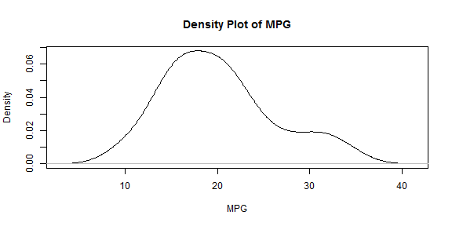

```r
plot(d, xlab = "MPG", main ="Density Plot of MPG")
```

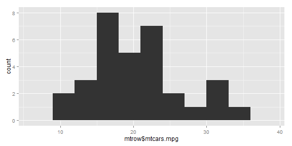

```r
mtrow<-data.frame(mtcars$mpg)
ggplot(mtrow, aes(x=mtrow$mtcars.mpg)) + geom_histogram(binwidth=3)
```

> Plot looks to be normal distribution

### Lets choose the predictors required for the model

Lets create a correlation matrix for all the predictors against **mpg**

```r
data(mtcars)
sort(cor(mtcars)[1,])
```

```
##         wt        cyl       disp         hp       carb       qsec
## -0.8676594 -0.8521620 -0.8475514 -0.7761684 -0.5509251  0.4186840
##       gear         am         vs       drat        mpg
##  0.4802848  0.5998324  0.6640389  0.6811719  1.0000000
```

- **am** by default is included in the model
- **wt**, **cyl**, **disp**, and **hp** are highly correlated with **mpg**
- we also see that **cyl** and **disp** are highly correlated with each other, which we cannot use as a predictor

## Performing Regression Analysis

### Simple Linear Regression

```r
Simplefit <- lm(mpg~am, data = mtcars)
summary(Simplefit)
```

```
##
## Call:
## lm(formula = mpg ~ am, data = mtcars)
##
## Residuals:
##     Min      1Q  Median      3Q     Max
## -9.3923 -3.0923 -0.2974  3.2439  9.5077
##
## Coefficients:
##             Estimate Std. Error t value Pr(>|t|)
## (Intercept)   17.147      1.125  15.247 1.13e-15 ***
## am             7.245      1.764   4.106 0.000285 ***
## ---
## Signif. codes:  0 '***' 0.001 '**' 0.01 '*' 0.05 '.' 0.1 ' ' 1
##
## Residual standard error: 4.902 on 30 degrees of freedom
## Multiple R-squared:  0.3598, Adjusted R-squared:  0.3385
## F-statistic: 16.86 on 1 and 30 DF,  p-value: 0.000285
```

- on average, automatic cars have 17.147 MPG and manual transmission cars have 7.245 MPGs more
- we see that the R^2 value is 0.3598
- This means that our model only explains 35.98% of the variance

### Multivariate Linear Regression

```r
Multivariatefit <- lm(mpg~am + wt + hp, data = mtcars)
anova(Simplefit, Multivariatefit)
```

```
## Analysis of Variance Table
##
## Model 1: mpg ~ am
## Model 2: mpg ~ am + wt + hp
##   Res.Df    RSS Df Sum of Sq      F    Pr(>F)
## 1     30 720.90
## 2     28 180.29  2    540.61 41.979 3.745e-09 ***
## ---
## Signif. codes:  0 '***' 0.001 '**' 0.01 '*' 0.05 '.' 0.1 ' ' 1
```

With a p-value of 3.745e-09, we reject the null hypothesis and claim that our multivariate model is significantly different from our simple model. Lets check the residuals before we derive any conclution

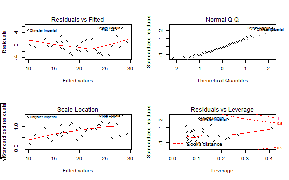

```r
par(mfrow = c(2,2))
plot(Multivariatefit)
```

They are normally distributed, so we can report on our final Model

```r
summary(Multivariatefit)
```

```
##
## Call:
## lm(formula = mpg ~ am + wt + hp, data = mtcars)
##
## Residuals:
##     Min      1Q  Median      3Q     Max
## -3.4221 -1.7924 -0.3788  1.2249  5.5317
##
## Coefficients:
##              Estimate Std. Error t value Pr(>|t|)
## (Intercept) 34.002875   2.642659  12.867 2.82e-13 ***
## am           2.083710   1.376420   1.514 0.141268
## wt          -2.878575   0.904971  -3.181 0.003574 **
## hp          -0.037479   0.009605  -3.902 0.000546 ***
## ---
## Signif. codes:  0 '***' 0.001 '**' 0.01 '*' 0.05 '.' 0.1 ' ' 1
##
## Residual standard error: 2.538 on 28 degrees of freedom
## Multiple R-squared:  0.8399, Adjusted R-squared:  0.8227
## F-statistic: 48.96 on 3 and 28 DF,  p-value: 2.908e-11
```

- This model explains over 83.99% of the variance.
- On average, manual transmission cars have 2.084 MPGs more than automatic transmission cars.